# Risk Factor Analysis

## Outcome Variable

**Outcome Variable:** ever_stunted

## Predictor Variables

**Intervention Variable:** birthlen

**Adjustment Set:**

unadjusted

## Stratifying Variables

The analysis was stratified on these variable(s):

- agecat
- studyid

The following strata were considered:

- agecat: 12 months, studyid: ki0047075b-MAL-ED
- agecat: 12 months, studyid: ki1000108-CMC-V-BCS-2002
- agecat: 12 months, studyid: ki1000108-IRC
- agecat: 12 months, studyid: ki1017093b-PROVIDE
- agecat: 12 months, studyid: ki1017093c-NIH-Crypto
- agecat: 12 months, studyid: ki1101329-Keneba
- agecat: 12 months, studyid: ki1126311-ZVITAMBO
- agecat: 12 months, studyid: ki1135781-COHORTS
- agecat: 18 months, studyid: ki0047075b-MAL-ED
- agecat: 18 months, studyid: ki1000108-CMC-V-BCS-2002
- agecat: 18 months, studyid: ki1000108-IRC
- agecat: 18 months, studyid: ki1017093b-PROVIDE
- agecat: 18 months, studyid: ki1017093c-NIH-Crypto
- agecat: 18 months, studyid: ki1101329-Keneba
- agecat: 18 months, studyid: ki1126311-ZVITAMBO
- agecat: 18 months, studyid: ki1135781-COHORTS
- agecat: 24 months, studyid: ki0047075b-MAL-ED
- agecat: 24 months, studyid: ki1000108-CMC-V-BCS-2002
- agecat: 24 months, studyid: ki1000108-IRC
- agecat: 24 months, studyid: ki1017093b-PROVIDE
- agecat: 24 months, studyid: ki1017093c-NIH-Crypto
- agecat: 24 months, studyid: ki1101329-Keneba
- agecat: 24 months, studyid: ki1126311-ZVITAMBO
- agecat: 24 months, studyid: ki1135781-COHORTS
- agecat: 3 months, studyid: ki0047075b-MAL-ED
- agecat: 3 months, studyid: ki1000108-CMC-V-BCS-2002
- agecat: 3 months, studyid: ki1000108-IRC
- agecat: 3 months, studyid: ki1017093b-PROVIDE
- agecat: 3 months, studyid: ki1017093c-NIH-Crypto
- agecat: 3 months, studyid: ki1101329-Keneba
- agecat: 3 months, studyid: ki1126311-ZVITAMBO
- agecat: 3 months, studyid: ki1135781-COHORTS
- agecat: 6 months, studyid: ki0047075b-MAL-ED
- agecat: 6 months, studyid: ki1000108-CMC-V-BCS-2002
- agecat: 6 months, studyid: ki1000108-IRC
- agecat: 6 months, studyid: ki1017093b-PROVIDE
- agecat: 6 months, studyid: ki1017093c-NIH-Crypto
- agecat: 6 months, studyid: ki1101329-Keneba
- agecat: 6 months, studyid: ki1126311-ZVITAMBO
- agecat: 6 months, studyid: ki1135781-COHORTS

### Dropped Strata

Some strata were dropped due to rare outcomes:

- agecat: 3 months, studyid: ki0047075b-MAL-ED
- agecat: 3 months, studyid: ki1000108-CMC-V-BCS-2002
- agecat: 3 months, studyid: ki1017093b-PROVIDE
- agecat: 3 months, studyid: ki1017093c-NIH-Crypto
- agecat: 6 months, studyid: ki0047075b-MAL-ED
- agecat: 6 months, studyid: ki1000108-CMC-V-BCS-2002
- agecat: 6 months, studyid: ki1017093b-PROVIDE
- agecat: 6 months, studyid: ki1017093c-NIH-Crypto
- agecat: 12 months, studyid: ki0047075b-MAL-ED
- agecat: 12 months, studyid: ki1000108-CMC-V-BCS-2002
- agecat: 12 months, studyid: ki1017093b-PROVIDE
- agecat: 12 months, studyid: ki1017093c-NIH-Crypto
- agecat: 18 months, studyid: ki0047075b-MAL-ED
- agecat: 18 months, studyid: ki1000108-CMC-V-BCS-2002
- agecat: 18 months, studyid: ki1000108-IRC
- agecat: 18 months, studyid: ki1017093b-PROVIDE
- agecat: 18 months, studyid: ki1017093c-NIH-Crypto
- agecat: 24 months, studyid: ki0047075b-MAL-ED
- agecat: 24 months, studyid: ki1000108-CMC-V-BCS-2002
- agecat: 24 months, studyid: ki1000108-IRC
- agecat: 24 months, studyid: ki1017093b-PROVIDE

## Methods Detail

We’re interested in the causal parameters $E[Y_a]$ for all values of $a \in \mathcal{A}$. These parameters represent the mean outcome if, possibly contrary to fact, we intervened to set all units to have $A=a$. Under the randomization and positivity assumptions, these are identified by the statistical parameters $\psi_a=E_W[E_{Y|A,W}(Y|A=a,W)]$. In addition, we’re interested in the mean of $Y$, $E[Y]$ under no intervention (the observed mean). We will estimate these parameters by using SuperLearner to fit the relevant likelihood factors – $E_{Y|A,W}(Y|A=a,W)$ and $p(A=a|W)$, and then updating our likelihood fit using a joint TMLE.

For unadjusted analyses ($W=\{\}$), initial likelihoods were estimated using Lrnr_glm to estimate the simple $E(Y|A)$ and Lrnr_mean to estimate $p(A)$. For adjusted analyses, a small library containing Lrnr_glmnet, Lrnr_xgboost, and Lrnr_mean was used.

Having estimated these parameters, we will then use the delta method to estimate relative risks and attributable risks relative to a prespecified baseline level of $A$.

# Results Detail

## Results Plots

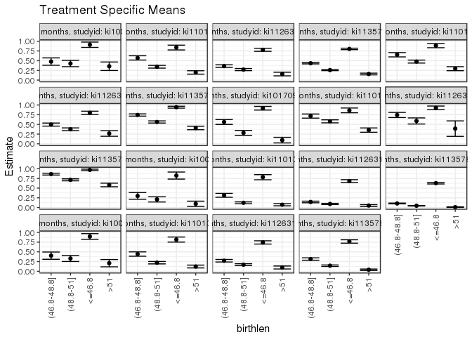

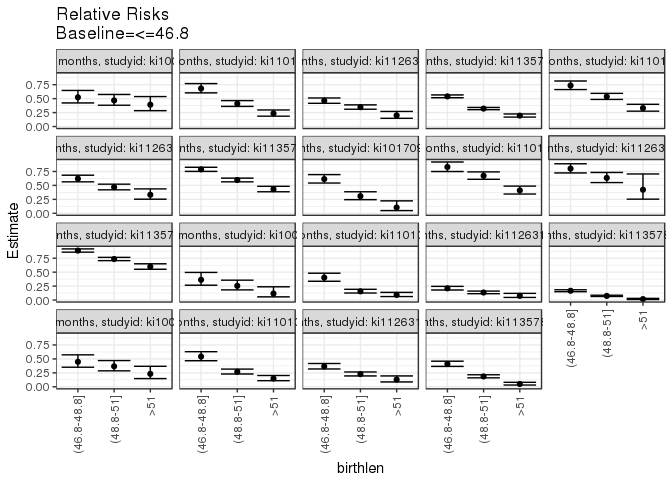

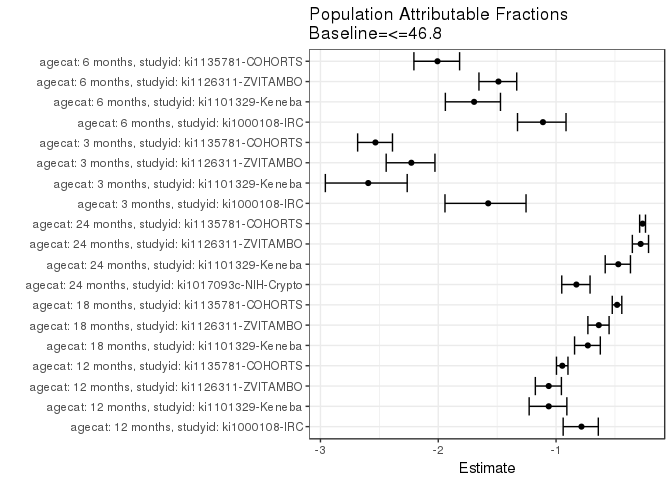

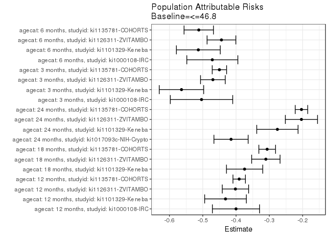

## Data Summary

| agecat | studyid | A | n | nA | nAY0 | nAY1 |
| --- | --- | --- | --- | --- | --- | --- |
| 3 months | ki0047075b-MAL-ED | <=46.8 | 54 | 20 | 9 | 11 |
| 3 months | ki0047075b-MAL-ED | (46.8-48.8] | 54 | 23 | 20 | 3 |
| 3 months | ki0047075b-MAL-ED | (48.8-51] | 54 | 11 | 11 | 0 |
| 3 months | ki0047075b-MAL-ED | >51 | 54 | 0 | 0 | 0 |
| 3 months | ki1000108-CMC-V-BCS-2002 | <=46.8 | 101 | 33 | 11 | 22 |
| 3 months | ki1000108-CMC-V-BCS-2002 | (46.8-48.8] | 101 | 32 | 23 | 9 |
| 3 months | ki1000108-CMC-V-BCS-2002 | (48.8-51] | 101 | 34 | 24 | 10 |
| 3 months | ki1000108-CMC-V-BCS-2002 | >51 | 101 | 2 | 2 | 0 |
| 3 months | ki1000108-IRC | <=46.8 | 391 | 68 | 12 | 56 |
| 3 months | ki1000108-IRC | (46.8-48.8] | 391 | 107 | 75 | 32 |
| 3 months | ki1000108-IRC | (48.8-51] | 391 | 143 | 113 | 30 |
| 3 months | ki1000108-IRC | >51 | 391 | 73 | 66 | 7 |
| 3 months | ki1017093b-PROVIDE | <=46.8 | 175 | 23 | 4 | 19 |
| 3 months | ki1017093b-PROVIDE | (46.8-48.8] | 175 | 67 | 47 | 20 |
| 3 months | ki1017093b-PROVIDE | (48.8-51] | 175 | 70 | 65 | 5 |
| 3 months | ki1017093b-PROVIDE | >51 | 175 | 15 | 15 | 0 |
| 3 months | ki1017093c-NIH-Crypto | <=46.8 | 758 | 151 | 44 | 107 |
| 3 months | ki1017093c-NIH-Crypto | (46.8-48.8] | 758 | 293 | 279 | 14 |
| 3 months | ki1017093c-NIH-Crypto | (48.8-51] | 758 | 243 | 243 | 0 |
| 3 months | ki1017093c-NIH-Crypto | >51 | 758 | 71 | 71 | 0 |
| 3 months | ki1101329-Keneba | <=46.8 | 1550 | 151 | 33 | 118 |
| 3 months | ki1101329-Keneba | (46.8-48.8] | 1550 | 337 | 231 | 106 |
| 3 months | ki1101329-Keneba | (48.8-51] | 1550 | 730 | 641 | 89 |
| 3 months | ki1101329-Keneba | >51 | 1550 | 332 | 308 | 24 |
| 3 months | ki1126311-ZVITAMBO | <=46.8 | 3473 | 629 | 201 | 428 |
| 3 months | ki1126311-ZVITAMBO | (46.8-48.8] | 3473 | 1098 | 941 | 157 |
| 3 months | ki1126311-ZVITAMBO | (48.8-51] | 3473 | 1414 | 1284 | 130 |
| 3 months | ki1126311-ZVITAMBO | >51 | 3473 | 332 | 315 | 17 |
| 3 months | ki1135781-COHORTS | <=46.8 | 10097 | 2015 | 750 | 1265 |
| 3 months | ki1135781-COHORTS | (46.8-48.8] | 10097 | 3341 | 2992 | 349 |

[output cut: 130 more lines]

## Results Table

### Parameter: TSM

| agecat | studyid | intervention_level | baseline_level | estimate | ci_lower | ci_upper |
| --- | --- | --- | --- | --- | --- | --- |
| 3 months | ki1000108-IRC | <=46.8 | NA | 0.8235294 | 0.7328047 | 0.9142541 |
| 3 months | ki1000108-IRC | (46.8-48.8] | NA | 0.2990654 | 0.2122026 | 0.3859283 |
| 3 months | ki1000108-IRC | (48.8-51] | NA | 0.2097902 | 0.1429712 | 0.2766092 |
| 3 months | ki1000108-IRC | >51 | NA | 0.0958904 | 0.0282602 | 0.1635206 |
| 3 months | ki1101329-Keneba | <=46.8 | NA | 0.7814570 | 0.7155212 | 0.8473927 |
| 3 months | ki1101329-Keneba | (46.8-48.8] | NA | 0.3145401 | 0.2649491 | 0.3641310 |
| 3 months | ki1101329-Keneba | (48.8-51] | NA | 0.1219178 | 0.0981752 | 0.1456604 |
| 3 months | ki1101329-Keneba | >51 | NA | 0.0722892 | 0.0444240 | 0.1001544 |
| 3 months | ki1126311-ZVITAMBO | <=46.8 | NA | 0.6804452 | 0.6439988 | 0.7168915 |
| 3 months | ki1126311-ZVITAMBO | (46.8-48.8] | NA | 0.1429872 | 0.1222786 | 0.1636959 |
| 3 months | ki1126311-ZVITAMBO | (48.8-51] | NA | 0.0919378 | 0.0768755 | 0.1070000 |
| 3 months | ki1126311-ZVITAMBO | >51 | NA | 0.0512048 | 0.0274920 | 0.0749176 |
| 3 months | ki1135781-COHORTS | <=46.8 | NA | 0.6277916 | 0.6066843 | 0.6488989 |
| 3 months | ki1135781-COHORTS | (46.8-48.8] | NA | 0.1044597 | 0.0940881 | 0.1148314 |
| 3 months | ki1135781-COHORTS | (48.8-51] | NA | 0.0465761 | 0.0396988 | 0.0534535 |
| 3 months | ki1135781-COHORTS | >51 | NA | 0.0105820 | 0.0046263 | 0.0165378 |
| 6 months | ki1000108-IRC | <=46.8 | NA | 0.8955224 | 0.8221860 | 0.9688588 |
| 6 months | ki1000108-IRC | (46.8-48.8] | NA | 0.4018692 | 0.3088536 | 0.4948847 |
| 6 months | ki1000108-IRC | (48.8-51] | NA | 0.3286713 | 0.2515832 | 0.4057595 |
| 6 months | ki1000108-IRC | >51 | NA | 0.2083333 | 0.1144061 | 0.3022605 |
| 6 months | ki1101329-Keneba | <=46.8 | NA | 0.8161765 | 0.7510553 | 0.8812976 |
| 6 months | ki1101329-Keneba | (46.8-48.8] | NA | 0.4429967 | 0.3874116 | 0.4985819 |
| 6 months | ki1101329-Keneba | (48.8-51] | NA | 0.2204380 | 0.1893836 | 0.2514923 |
| 6 months | ki1101329-Keneba | >51 | NA | 0.1217949 | 0.0854926 | 0.1580972 |
| 6 months | ki1126311-ZVITAMBO | <=46.8 | NA | 0.7420925 | 0.6997882 | 0.7843967 |
| 6 months | ki1126311-ZVITAMBO | (46.8-48.8] | NA | 0.2713287 | 0.2387296 | 0.3039277 |
| 6 months | ki1126311-ZVITAMBO | (48.8-51] | NA | 0.1690450 | 0.1447020 | 0.1933880 |
| 6 months | ki1126311-ZVITAMBO | >51 | NA | 0.0969163 | 0.0584223 | 0.1354103 |
| 6 months | ki1135781-COHORTS | <=46.8 | NA | 0.7673130 | 0.7237176 | 0.8109085 |
| 6 months | ki1135781-COHORTS | (46.8-48.8] | NA | 0.3144509 | 0.2835045 | 0.3453973 |
| 6 months | ki1135781-COHORTS | (48.8-51] | NA | 0.1429706 | 0.1236318 | 0.1623095 |
| 6 months | ki1135781-COHORTS | >51 | NA | 0.0388128 | 0.0207212 | 0.0569044 |
| 12 months | ki1000108-IRC | <=46.8 | NA | 0.9104478 | 0.8419882 | 0.9789073 |
| 12 months | ki1000108-IRC | (46.8-48.8] | NA | 0.4766355 | 0.3818790 | 0.5713920 |
| 12 months | ki1000108-IRC | (48.8-51] | NA | 0.4265734 | 0.3454076 | 0.5077393 |
| 12 months | ki1000108-IRC | >51 | NA | 0.3561644 | 0.2461734 | 0.4661553 |
| 12 months | ki1101329-Keneba | <=46.8 | NA | 0.8382353 | 0.7763263 | 0.9001442 |
| 12 months | ki1101329-Keneba | (46.8-48.8] | NA | 0.5714286 | 0.5161426 | 0.6267146 |
| 12 months | ki1101329-Keneba | (48.8-51] | NA | 0.3434783 | 0.3080339 | 0.3789227 |
| 12 months | ki1101329-Keneba | >51 | NA | 0.1968254 | 0.1529028 | 0.2407480 |
| 12 months | ki1126311-ZVITAMBO | <=46.8 | NA | 0.7803204 | 0.7414942 | 0.8191466 |
| 12 months | ki1126311-ZVITAMBO | (46.8-48.8] | NA | 0.3606755 | 0.3279809 | 0.3933701 |
| 12 months | ki1126311-ZVITAMBO | (48.8-51] | NA | 0.2708538 | 0.2435626 | 0.2981449 |
| 12 months | ki1126311-ZVITAMBO | >51 | NA | 0.1558442 | 0.1090615 | 0.2026268 |
| 12 months | ki1135781-COHORTS | <=46.8 | NA | 0.8030719 | 0.7848157 | 0.8213280 |
| 12 months | ki1135781-COHORTS | (46.8-48.8] | NA | 0.4344156 | 0.4169092 | 0.4519220 |
| 12 months | ki1135781-COHORTS | (48.8-51] | NA | 0.2581032 | 0.2432443 | 0.2729622 |
| 12 months | ki1135781-COHORTS | >51 | NA | 0.1568816 | 0.1347663 | 0.1789970 |
| 18 months | ki1101329-Keneba | <=46.8 | NA | 0.8872180 | 0.8334386 | 0.9409974 |
| 18 months | ki1101329-Keneba | (46.8-48.8] | NA | 0.6526316 | 0.5973331 | 0.7079301 |
| 18 months | ki1101329-Keneba | (48.8-51] | NA | 0.4768519 | 0.4383817 | 0.5153220 |
| 18 months | ki1101329-Keneba | >51 | NA | 0.2937294 | 0.2424261 | 0.3450326 |
| 18 months | ki1126311-ZVITAMBO | <=46.8 | NA | 0.7977208 | 0.7556855 | 0.8397561 |
| 18 months | ki1126311-ZVITAMBO | (46.8-48.8] | NA | 0.4951456 | 0.4557161 | 0.5345752 |
| 18 months | ki1126311-ZVITAMBO | (48.8-51] | NA | 0.3741307 | 0.3387509 | 0.4095105 |
| 18 months | ki1126311-ZVITAMBO | >51 | NA | 0.2653061 | 0.1939166 | 0.3366957 |
| 18 months | ki1135781-COHORTS | <=46.8 | NA | 0.9428571 | 0.9185355 | 0.9671788 |
| 18 months | ki1135781-COHORTS | (46.8-48.8] | NA | 0.7423529 | 0.7129473 | 0.7717586 |
| 18 months | ki1135781-COHORTS | (48.8-51] | NA | 0.5622490 | 0.5346867 | 0.5898113 |
| 18 months | ki1135781-COHORTS | >51 | NA | 0.4078091 | 0.3629416 | 0.4526766 |
| 24 months | ki1017093c-NIH-Crypto | <=46.8 | NA | 0.9166667 | 0.8694800 | 0.9638533 |
| 24 months | ki1017093c-NIH-Crypto | (46.8-48.8] | NA | 0.5625000 | 0.4996890 | 0.6253110 |
| 24 months | ki1017093c-NIH-Crypto | (48.8-51] | NA | 0.2814070 | 0.2188792 | 0.3439349 |
| 24 months | ki1017093c-NIH-Crypto | >51 | NA | 0.0952381 | 0.0226955 | 0.1677807 |
| 24 months | ki1101329-Keneba | <=46.8 | NA | 0.8606557 | 0.7991814 | 0.9221301 |
| 24 months | ki1101329-Keneba | (46.8-48.8] | NA | 0.7142857 | 0.6613513 | 0.7672201 |
| 24 months | ki1101329-Keneba | (48.8-51] | NA | 0.5788618 | 0.5398247 | 0.6178988 |
| 24 months | ki1101329-Keneba | >51 | NA | 0.3531469 | 0.2977338 | 0.4085599 |
| 24 months | ki1126311-ZVITAMBO | <=46.8 | NA | 0.9262295 | 0.8797955 | 0.9726635 |
| 24 months | ki1126311-ZVITAMBO | (46.8-48.8] | NA | 0.7425150 | 0.6761275 | 0.8089024 |
| 24 months | ki1126311-ZVITAMBO | (48.8-51] | NA | 0.5882353 | 0.5101679 | 0.6663027 |
| 24 months | ki1126311-ZVITAMBO | >51 | NA | 0.3913043 | 0.1916361 | 0.5909726 |
| 24 months | ki1135781-COHORTS | <=46.8 | NA | 0.9701493 | 0.9519229 | 0.9883756 |
| 24 months | ki1135781-COHORTS | (46.8-48.8] | NA | 0.8607748 | 0.8371625 | 0.8843871 |
| 24 months | ki1135781-COHORTS | (48.8-51] | NA | 0.7135843 | 0.6882324 | 0.7389362 |
| 24 months | ki1135781-COHORTS | >51 | NA | 0.5812357 | 0.5349715 | 0.6274999 |

### Parameter: E(Y)

| agecat | studyid | intervention_level | baseline_level | estimate | ci_lower | ci_upper |
| --- | --- | --- | --- | --- | --- | --- |
| 3 months | ki1000108-IRC | NA | NA | 0.3196931 | 0.2957845 | 0.3436017 |
| 3 months | ki1101329-Keneba | NA | NA | 0.2174194 | 0.2072317 | 0.2276070 |
| 3 months | ki1126311-ZVITAMBO | NA | NA | 0.2107688 | 0.2033617 | 0.2181759 |
| 3 months | ki1135781-COHORTS | NA | NA | 0.1776765 | 0.1732506 | 0.1821024 |
| 6 months | ki1000108-IRC | NA | NA | 0.4241645 | 0.4018312 | 0.4464979 |
| 6 months | ki1101329-Keneba | NA | NA | 0.3027778 | 0.2925211 | 0.3130344 |
| 6 months | ki1126311-ZVITAMBO | NA | NA | 0.2981449 | 0.2892344 | 0.3070554 |
| 6 months | ki1135781-COHORTS | NA | NA | 0.2552172 | 0.2474517 | 0.2629828 |
| 12 months | ki1000108-IRC | NA | NA | 0.5102564 | 0.4917089 | 0.5288039 |
| 12 months | ki1101329-Keneba | NA | NA | 0.4064872 | 0.3968891 | 0.4160854 |
| 12 months | ki1126311-ZVITAMBO | NA | NA | 0.3783784 | 0.3708209 | 0.3859358 |
| 12 months | ki1135781-COHORTS | NA | NA | 0.4124434 | 0.4080766 | 0.4168102 |
| 18 months | ki1101329-Keneba | NA | NA | 0.5127831 | 0.5037708 | 0.5217953 |
| 18 months | ki1126311-ZVITAMBO | NA | NA | 0.4871935 | 0.4796151 | 0.4947718 |
| 18 months | ki1135781-COHORTS | NA | NA | 0.6362698 | 0.6304926 | 0.6420470 |
| 24 months | ki1017093c-NIH-Crypto | NA | NA | 0.5015773 | 0.4811290 | 0.5220256 |
| 24 months | ki1101329-Keneba | NA | NA | 0.5848043 | 0.5766524 | 0.5929562 |
| 24 months | ki1126311-ZVITAMBO | NA | NA | 0.7225806 | 0.7089655 | 0.7361958 |
| 24 months | ki1135781-COHORTS | NA | NA | 0.7666667 | 0.7622892 | 0.7710442 |

### Parameter: RR

| agecat | studyid | intervention_level | baseline_level | estimate | ci_lower | ci_upper |
| --- | --- | --- | --- | --- | --- | --- |
| 3 months | ki1000108-IRC | (46.8-48.8] | <=46.8 | 0.3631509 | 0.2661819 | 0.4954453 |
| 3 months | ki1000108-IRC | (48.8-51] | <=46.8 | 0.2547453 | 0.1818616 | 0.3568381 |
| 3 months | ki1000108-IRC | >51 | <=46.8 | 0.1164384 | 0.0570269 | 0.2377455 |
| 3 months | ki1101329-Keneba | (46.8-48.8] | <=46.8 | 0.4025047 | 0.3365972 | 0.4813171 |
| 3 months | ki1101329-Keneba | (48.8-51] | <=46.8 | 0.1560135 | 0.1261797 | 0.1929011 |
| 3 months | ki1101329-Keneba | >51 | <=46.8 | 0.0925056 | 0.0623444 | 0.1372583 |
| 3 months | ki1126311-ZVITAMBO | (46.8-48.8] | <=46.8 | 0.2101378 | 0.1800703 | 0.2452258 |
| 3 months | ki1126311-ZVITAMBO | (48.8-51] | <=46.8 | 0.1351141 | 0.1137218 | 0.1605306 |
| 3 months | ki1126311-ZVITAMBO | >51 | <=46.8 | 0.0752519 | 0.0472124 | 0.1199442 |
| 3 months | ki1135781-COHORTS | (46.8-48.8] | <=46.8 | 0.1663924 | 0.1498331 | 0.1847818 |
| 3 months | ki1135781-COHORTS | (48.8-51] | <=46.8 | 0.0741904 | 0.0637645 | 0.0863210 |
| 3 months | ki1135781-COHORTS | >51 | <=46.8 | 0.0168559 | 0.0095915 | 0.0296222 |
| 6 months | ki1000108-IRC | (46.8-48.8] | <=46.8 | 0.4487539 | 0.3510600 | 0.5736343 |
| 6 months | ki1000108-IRC | (48.8-51] | <=46.8 | 0.3670163 | 0.2862816 | 0.4705191 |
| 6 months | ki1000108-IRC | >51 | <=46.8 | 0.2326389 | 0.1471217 | 0.3678646 |
| 6 months | ki1101329-Keneba | (46.8-48.8] | <=46.8 | 0.5427708 | 0.4677772 | 0.6297873 |
| 6 months | ki1101329-Keneba | (48.8-51] | <=46.8 | 0.2700861 | 0.2297150 | 0.3175523 |
| 6 months | ki1101329-Keneba | >51 | <=46.8 | 0.1492261 | 0.1096077 | 0.2031650 |
| 6 months | ki1126311-ZVITAMBO | (46.8-48.8] | <=46.8 | 0.3656265 | 0.3200983 | 0.4176303 |
| 6 months | ki1126311-ZVITAMBO | (48.8-51] | <=46.8 | 0.2277951 | 0.1951113 | 0.2659539 |
| 6 months | ki1126311-ZVITAMBO | >51 | <=46.8 | 0.1305987 | 0.0874328 | 0.1950757 |
| 6 months | ki1135781-COHORTS | (46.8-48.8] | <=46.8 | 0.4098078 | 0.3657871 | 0.4591263 |
| 6 months | ki1135781-COHORTS | (48.8-51] | <=46.8 | 0.1863263 | 0.1609007 | 0.2157698 |
| 6 months | ki1135781-COHORTS | >51 | <=46.8 | 0.0505827 | 0.0316278 | 0.0808976 |
| 12 months | ki1000108-IRC | (46.8-48.8] | <=46.8 | 0.5235177 | 0.4232754 | 0.6475000 |
| 12 months | ki1000108-IRC | (48.8-51] | <=46.8 | 0.4685315 | 0.3818433 | 0.5749000 |
| 12 months | ki1000108-IRC | >51 | <=46.8 | 0.3911970 | 0.2846806 | 0.5375675 |
| 12 months | ki1101329-Keneba | (46.8-48.8] | <=46.8 | 0.6817043 | 0.6035792 | 0.7699415 |
| 12 months | ki1101329-Keneba | (48.8-51] | <=46.8 | 0.4097635 | 0.3609289 | 0.4652057 |
| 12 months | ki1101329-Keneba | >51 | <=46.8 | 0.2348092 | 0.1856223 | 0.2970300 |
| 12 months | ki1126311-ZVITAMBO | (46.8-48.8] | <=46.8 | 0.4622147 | 0.4168070 | 0.5125691 |
| 12 months | ki1126311-ZVITAMBO | (48.8-51] | <=46.8 | 0.3471059 | 0.3102115 | 0.3883882 |
| 12 months | ki1126311-ZVITAMBO | >51 | <=46.8 | 0.1997182 | 0.1473223 | 0.2707489 |
| 12 months | ki1135781-COHORTS | (46.8-48.8] | <=46.8 | 0.5409424 | 0.5164839 | 0.5665590 |
| 12 months | ki1135781-COHORTS | (48.8-51] | <=46.8 | 0.3213950 | 0.3021052 | 0.3419164 |
| 12 months | ki1135781-COHORTS | >51 | <=46.8 | 0.1953519 | 0.1693577 | 0.2253359 |
| 18 months | ki1101329-Keneba | (46.8-48.8] | <=46.8 | 0.7355932 | 0.6628151 | 0.8163625 |
| 18 months | ki1101329-Keneba | (48.8-51] | <=46.8 | 0.5374686 | 0.4858795 | 0.5945352 |
| 18 months | ki1101329-Keneba | >51 | <=46.8 | 0.3310679 | 0.2751847 | 0.3982995 |
| 18 months | ki1126311-ZVITAMBO | (46.8-48.8] | <=46.8 | 0.6207004 | 0.5641727 | 0.6828919 |
| 18 months | ki1126311-ZVITAMBO | (48.8-51] | <=46.8 | 0.4689996 | 0.4208794 | 0.5226216 |
| 18 months | ki1126311-ZVITAMBO | >51 | <=46.8 | 0.3325802 | 0.2528222 | 0.4374995 |
| 18 months | ki1135781-COHORTS | (46.8-48.8] | <=46.8 | 0.7873440 | 0.7509920 | 0.8254557 |
| 18 months | ki1135781-COHORTS | (48.8-51] | <=46.8 | 0.5963247 | 0.5641899 | 0.6302898 |
| 18 months | ki1135781-COHORTS | >51 | <=46.8 | 0.4325248 | 0.3863081 | 0.4842707 |
| 24 months | ki1017093c-NIH-Crypto | (46.8-48.8] | <=46.8 | 0.6136364 | 0.5426392 | 0.6939226 |
| 24 months | ki1017093c-NIH-Crypto | (48.8-51] | <=46.8 | 0.3069895 | 0.2443818 | 0.3856366 |
| 24 months | ki1017093c-NIH-Crypto | >51 | <=46.8 | 0.1038961 | 0.0484221 | 0.2229229 |
| 24 months | ki1101329-Keneba | (46.8-48.8] | <=46.8 | 0.8299320 | 0.7487590 | 0.9199049 |
| 24 months | ki1101329-Keneba | (48.8-51] | <=46.8 | 0.6725823 | 0.6096540 | 0.7420060 |
| 24 months | ki1101329-Keneba | >51 | <=46.8 | 0.4103230 | 0.3453437 | 0.4875287 |
| 24 months | ki1126311-ZVITAMBO | (46.8-48.8] | <=46.8 | 0.8016533 | 0.7235514 | 0.8881857 |
| 24 months | ki1126311-ZVITAMBO | (48.8-51] | <=46.8 | 0.6350859 | 0.5510870 | 0.7318883 |
| 24 months | ki1126311-ZVITAMBO | >51 | <=46.8 | 0.4224702 | 0.2530023 | 0.7054522 |
| 24 months | ki1135781-COHORTS | (46.8-48.8] | <=46.8 | 0.8872602 | 0.8582454 | 0.9172559 |
| 24 months | ki1135781-COHORTS | (48.8-51] | <=46.8 | 0.7355407 | 0.7065661 | 0.7657035 |
| 24 months | ki1135781-COHORTS | >51 | <=46.8 | 0.5991199 | 0.5520719 | 0.6501773 |

### Parameter: PAR

| agecat | studyid | intervention_level | baseline_level | estimate | ci_lower | ci_upper |
| --- | --- | --- | --- | --- | --- | --- |
| 3 months | ki1000108-IRC | <=46.8 | NA | -0.5038363 | -0.5976584 | -0.4100142 |
| 3 months | ki1101329-Keneba | <=46.8 | NA | -0.5640376 | -0.6307557 | -0.4973195 |
| 3 months | ki1126311-ZVITAMBO | <=46.8 | NA | -0.4696764 | -0.5068678 | -0.4324849 |
| 3 months | ki1135781-COHORTS | <=46.8 | NA | -0.4501150 | -0.4716814 | -0.4285487 |
| 6 months | ki1000108-IRC | <=46.8 | NA | -0.4713579 | -0.5480195 | -0.3946963 |
| 6 months | ki1101329-Keneba | <=46.8 | NA | -0.5133987 | -0.5793226 | -0.4474748 |
| 6 months | ki1126311-ZVITAMBO | <=46.8 | NA | -0.4439476 | -0.4871801 | -0.4007151 |
| 6 months | ki1135781-COHORTS | <=46.8 | NA | -0.5120958 | -0.5563775 | -0.4678141 |
| 12 months | ki1000108-IRC | <=46.8 | NA | -0.4001913 | -0.4711189 | -0.3292638 |
| 12 months | ki1101329-Keneba | <=46.8 | NA | -0.4317481 | -0.4943966 | -0.3690995 |
| 12 months | ki1126311-ZVITAMBO | <=46.8 | NA | -0.4019420 | -0.4414969 | -0.3623871 |
| 12 months | ki1135781-COHORTS | <=46.8 | NA | -0.3906285 | -0.4093996 | -0.3718573 |
| 18 months | ki1101329-Keneba | <=46.8 | NA | -0.3744350 | -0.4289643 | -0.3199057 |
| 18 months | ki1126311-ZVITAMBO | <=46.8 | NA | -0.3105273 | -0.3532403 | -0.2678144 |
| 18 months | ki1135781-COHORTS | <=46.8 | NA | -0.3065874 | -0.3315857 | -0.2815890 |
| 24 months | ki1017093c-NIH-Crypto | <=46.8 | NA | -0.4150894 | -0.4665161 | -0.3636626 |
| 24 months | ki1101329-Keneba | <=46.8 | NA | -0.2758514 | -0.3378640 | -0.2138389 |
| 24 months | ki1126311-ZVITAMBO | <=46.8 | NA | -0.2036489 | -0.2520378 | -0.1552599 |
| 24 months | ki1135781-COHORTS | <=46.8 | NA | -0.2034826 | -0.2222272 | -0.1847379 |

### Parameter: PAF

| agecat | studyid | intervention_level | baseline_level | estimate | ci_lower | ci_upper |
| --- | --- | --- | --- | --- | --- | --- |
| 3 months | ki1000108-IRC | <=46.8 | NA | -1.5760000 | -1.9428832 | -1.2548553 |
| 3 months | ki1101329-Keneba | <=46.8 | NA | -2.5942382 | -2.9584211 | -2.2635609 |
| 3 months | ki1126311-ZVITAMBO | <=46.8 | NA | -2.2283962 | -2.4419833 | -2.0280629 |
| 3 months | ki1135781-COHORTS | <=46.8 | NA | -2.5333397 | -2.6843250 | -2.3885418 |
| 6 months | ki1000108-IRC | <=46.8 | NA | -1.1112619 | -1.3271494 | -0.9154020 |
| 6 months | ki1101329-Keneba | <=46.8 | NA | -1.6956287 | -1.9397157 | -1.4718085 |
| 6 months | ki1126311-ZVITAMBO | <=46.8 | NA | -1.4890331 | -1.6545103 | -1.3338714 |
| 6 months | ki1135781-COHORTS | <=46.8 | NA | -2.0065093 | -2.2066605 | -1.8188510 |
| 12 months | ki1000108-IRC | <=46.8 | NA | -0.7842946 | -0.9397158 | -0.6413267 |
| 12 months | ki1101329-Keneba | <=46.8 | NA | -1.0621442 | -1.2284033 | -0.9082896 |
| 12 months | ki1126311-ZVITAMBO | <=46.8 | NA | -1.0622753 | -1.1758639 | -0.9546164 |
| 12 months | ki1135781-COHORTS | <=46.8 | NA | -0.9471081 | -0.9965541 | -0.8988866 |
| 18 months | ki1101329-Keneba | <=46.8 | NA | -0.7302016 | -0.8429180 | -0.6243791 |
| 18 months | ki1126311-ZVITAMBO | <=46.8 | NA | -0.6373799 | -0.7298584 | -0.5498454 |
| 18 months | ki1135781-COHORTS | <=46.8 | NA | -0.4818512 | -0.5229346 | -0.4418761 |
| 24 months | ki1017093c-NIH-Crypto | <=46.8 | NA | -0.8275681 | -0.9516024 | -0.7114169 |
| 24 months | ki1101329-Keneba | <=46.8 | NA | -0.4716987 | -0.5827949 | -0.3684004 |
| 24 months | ki1126311-ZVITAMBO | <=46.8 | NA | -0.2818355 | -0.3523575 | -0.2149910 |
| 24 months | ki1135781-COHORTS | <=46.8 | NA | -0.2654121 | -0.2905048 | -0.2408072 |